# Lab12_report

François Birgand

4/8/2021

# Exercise 1: Explore the content of the data and first plot

I was given a first file (“infreq_Exp06_Rep2_U0.csv”) of nitrate concentration decrease over time in a mesocosm experiment.

The data provided in this lab comes from an experiment which was part of the MS thesis from Mr. Marc Horstman. Intact sediment mesocosms were obtained from the field, brought back to the lab. Ten centimeters of water were added on top of the sediment, spiked with nitrate, and recirculated at variable velocities. Nitrate concentrations were measured over time.

First I plotted the nitrate concentration decrease as a function of time expressed in days.

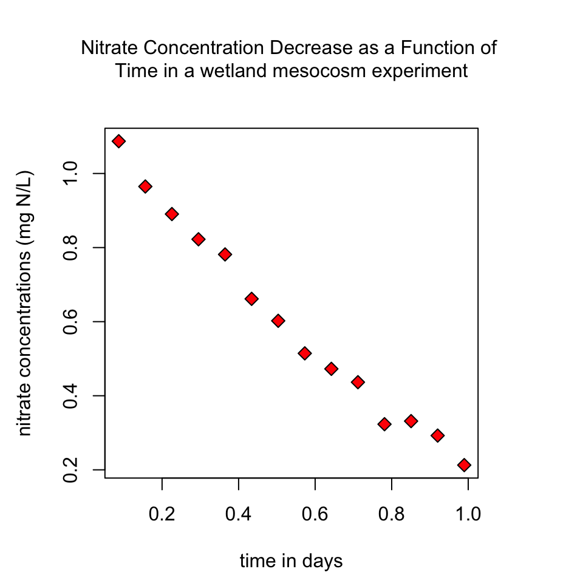

I expect you to write in the text greek letters and equations. So when in doubt for Greek letters, you may find solution [here](https://francoisbirgand.github.io/tutorial-RMarkdown_instructions.html#symbols_and_special_characters), and for equations [there](https://francoisbirgand.github.io/tutorial-RMarkdown_instructions.html#editing_equations_in_r_markdown)

So I want to see ρ or $\rho$ and not rho. And for equations, I want to see something like:

$$C=C_0e^{-\frac{\rho}{D}t}$$

# Exercise 2 : Fitting a first order rate model for nitrate removal in a wetland

The plot for the linearized data might look like this

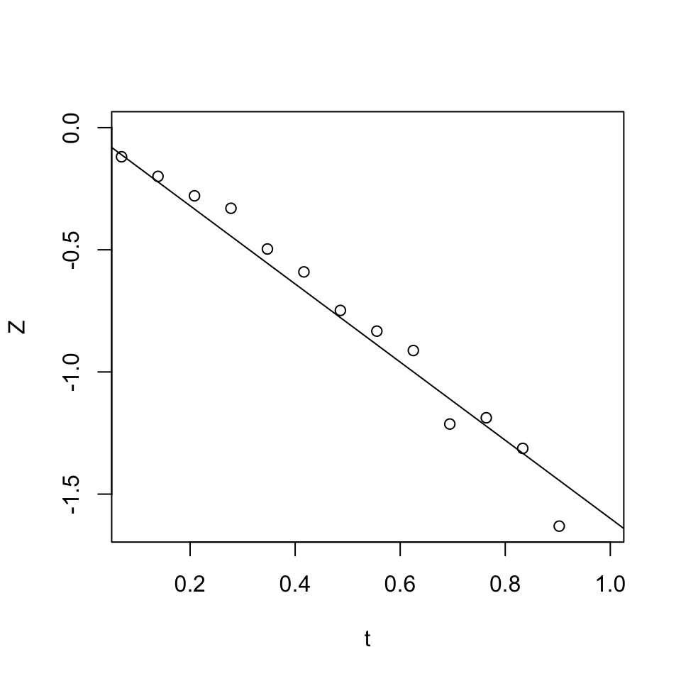

# Exercise 3 : Fitting a first order rate model by calculating mass transfer coefficient

Below is plotted concentration of nitrate over time, with an exponential linear regression model.

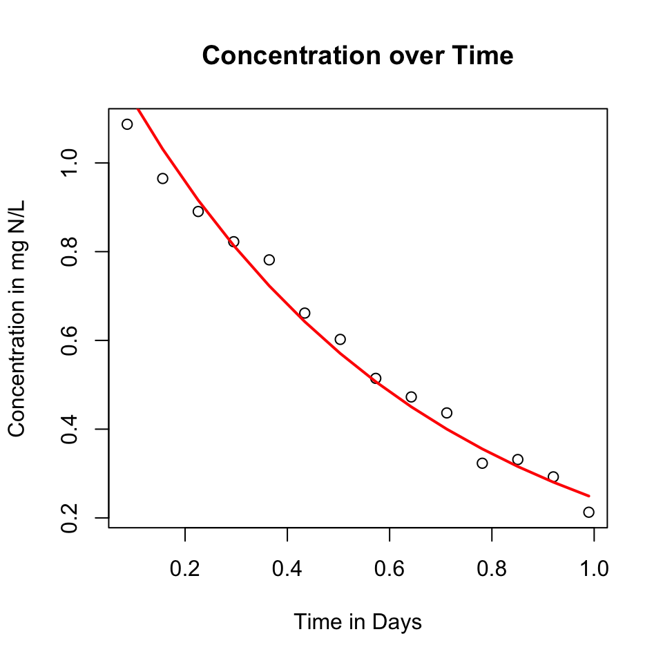

# Exercice 4: Treatment time for stagnant water

# Exercise 5: Treatment time for water recirculated at 3 cm/s

```r
data2<-read.csv(file="Exp03_Rep3_U3.csv",header = TRUE) #Reads file into table format
```

For this we use another set of data using the file “Exp03_Rep3_U3.csv”. Very similarly to what was done for stagnant water, I have first plotted the concentration as a function of time.

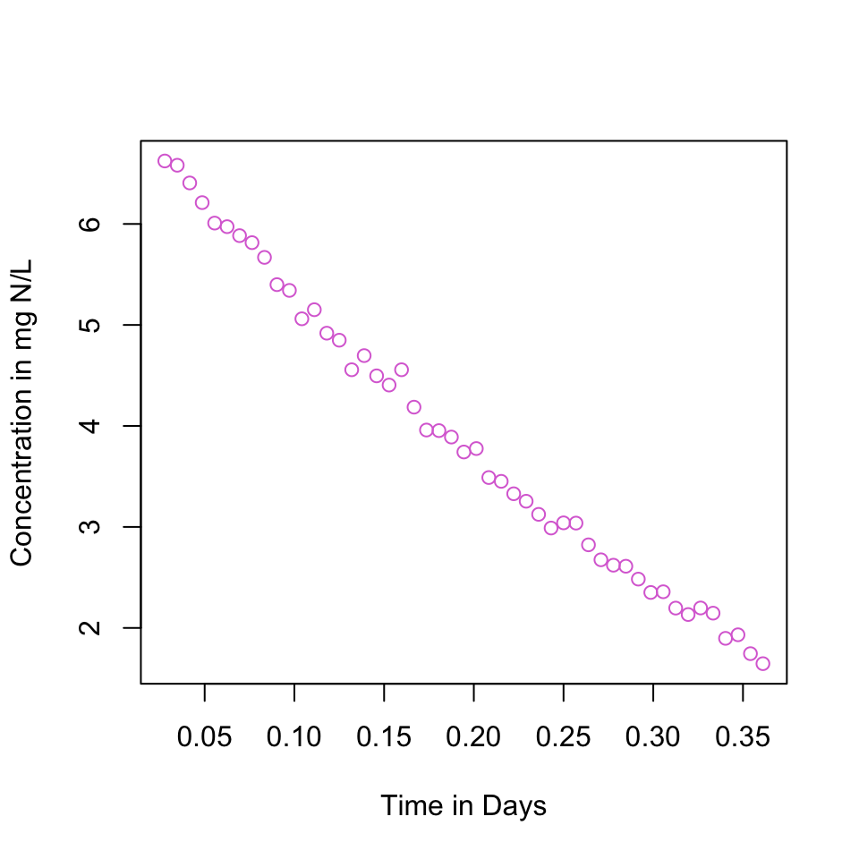

The linearization of the data might look like this:

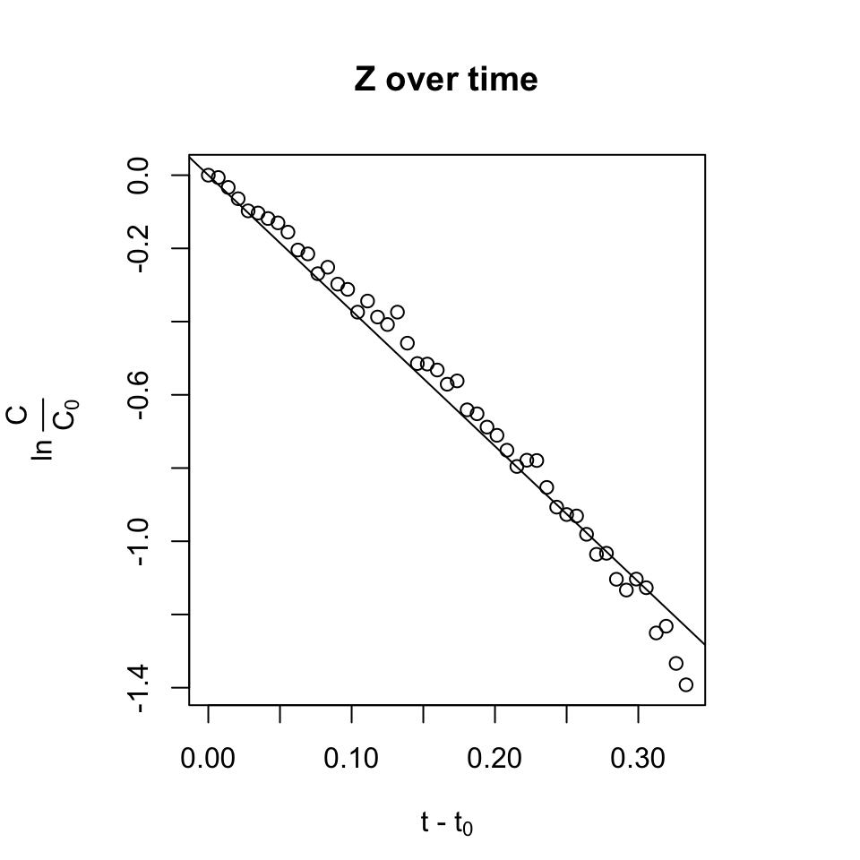

And the final graph may look like this:

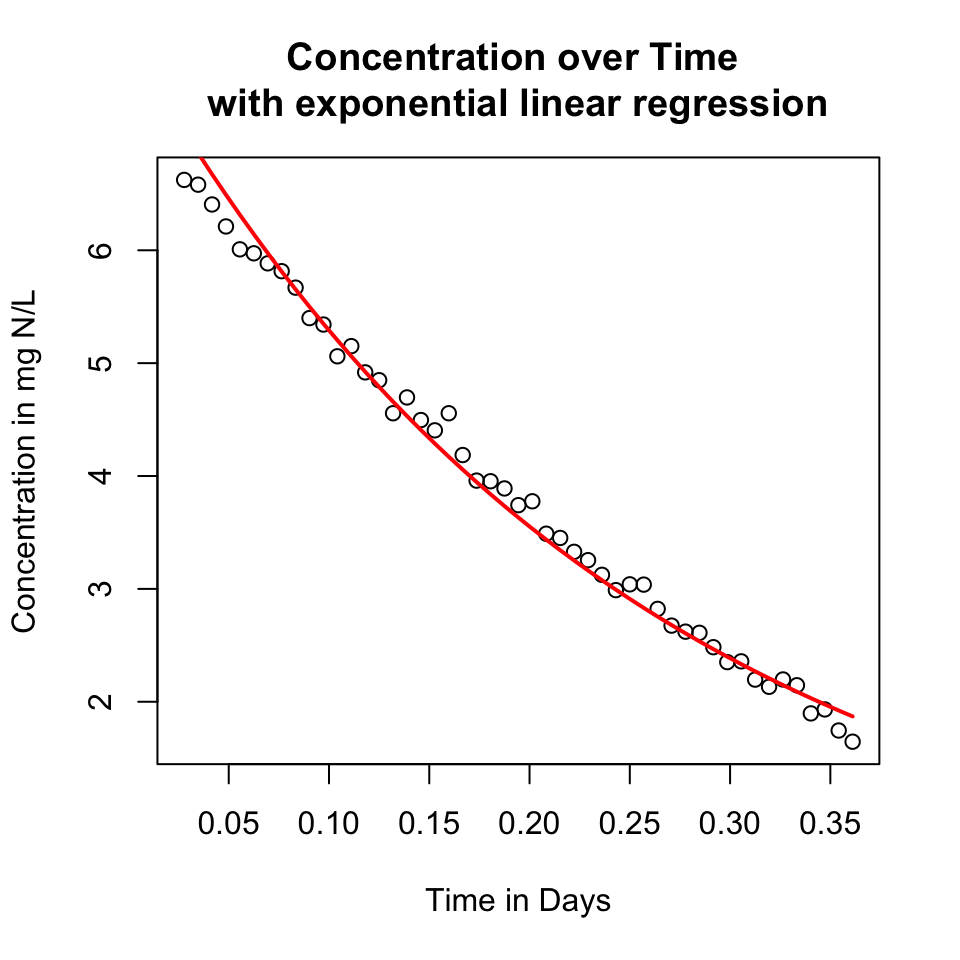

## Exercise 6: Discuss your observations